# Background of Rubella Vaccination

Preview

Hiroki Kato

ワクチン接種には、予防接種法で規定されている定期接種とそれ以外の任意接種がある。 定期接種は原則として自己負担がないが、任意接種は接種料金を自己負担する必要がある。 1994年の予防接種法の改正により、定期接種は義務接種から努力接種へと変更された。

感染予防効果を持つ風しんワクチンは、 妊婦の感染防止のために1977年8月から定期接種の対象となった。 この時期から中学生の女子を対象に1回の定期接種が行われた。 1989年4月から、 中学生女子を対象とした定期接種と同時に、 生後12-72カ月の幼児が麻疹ワクチンの定期接種を受けるとき、 親は麻しん・おたふくかぜ・風しん混合ワクチン（MMRワクチン）を選択することができた。 しかしながら、無菌性髄膜炎の副作用の多発により、 MMRワクチンの義務接種としての定期接種は1993年4月に一旦中止された。 その後、1995年4月から経過措置とともに努力義務としての定期接種が再開された[^1]。

その結果、日本では風しんワクチンの定期接種を受けていない2つの年齢層が生じることになった。 定期接種を受けていない世代は、(1)1962年4月2日以前に生まれた男女と (2)1962年4月2日から1979年4月1日に生まれた男性である[^2]。 1979年4月2日以降に生まれた男女は経過措置を含めて定期接種の対象者となっているが、接種回数は年齢によって異なる。 定期接種を受けていない人は自然感染による抗体保有の可能性があるだけで、ワクチン接種による風しん抗体を保有していない。

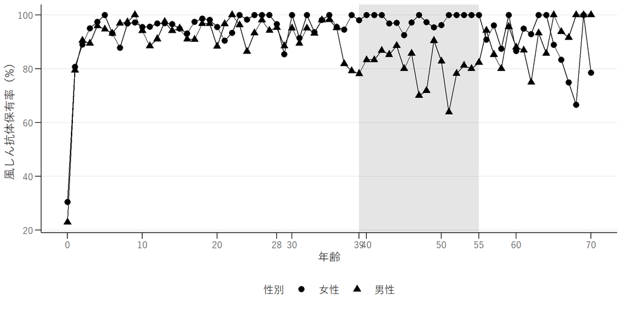

Figure 1: 男女別の各年齢における風しん抗体保有率。データソース: 国立感染症研究所『2018年度感染症流行予測調査（NESVPD）』

風しんの抗体はワクチン接種だけでなく、自然感染でも得られる。 高齢者を中心に、風しんが流行していた期間に育った人ほど、風しんに自然感染した比率が高くなるので、 風しんワクチンを接種していなくても抗体を保有している可能性が高くなる。 図1は国立感染症研究所（NIID）の 2018年度感染症流行予測調査の男女別・年齢別の風しん抗体保有率をプロットしたものである。 56歳以上の各年齢の抗体保有率の平均は、男女とも約90%である（男性： 91.3% 、女性： 89.4% ）。 一方、39歳以上55歳以下の（1962年4月2日から1979年4月1日生まれ）の抗体保有率の平均は、 男性では、 80.7% 、女性では、 98.3% である。 つまり、この年齢層の男性の抗体保有率は同世代の女性の抗体保有率より低い。 これは39歳以上55歳以下の男性は風しんワクチンの定期接種の対象外である一方、 39歳以上55歳以下の女性は中学生のときに風しんワクチンを接種していることを反映している。 また、39歳以上55歳以下の男性の抗体保有率は56歳以上の男性のそれよりも低い。 これは56歳以上の男性は、風しんの流行時期に育ったために風しんに自然感染する確率が高かったことを反映している[^3]。

この現状を踏まえて、 厚生労働省は風しんの集団免疫を獲得するために、 2019年4月から2022年3月までの間で、風しん定期接種の追加対策を実施することを決めた。 対象者は抗体保有率が低い1962年4月2日から1979年4月1日生まれの男性（2019年4月時点で40歳から57歳の男性）である。 ワクチン接種の効率的な活用のために、対象の男性は、はじめに抗体検査を受検する。 抗体検査により抗体が持っていないことが明らかになった男性は風しんワクチンを接種する。 この追加対策の目標は、2022年3月までに、対象世代の男性の抗体保有率を90%に引き上げることである。 この目標が達成されれば、すべての世代で抗体保有率が90%を超え、日本で集団免疫が獲得できる(Kinoshita and Nishiura 2016)[^4]。

Kinoshita, Ryo, and Hiroshi Nishiura. 2016. “Assessing Herd Immunity Against Rubella in Japan: A Retrospective Seroepidemiological Analysis of Age-Dependent Transmission Dynamics.” *BMJ Open* 6 (1): e009928. https://doi.org/10.1136/bmjopen-2015-009928.

Nishiura, Hiroshi, Ryo Kinoshita, Yuichiro Miyamatsu, and Kenji Mizumoto. 2015. “Investigating the Immunizing Effect of the Rubella Epidemic in Japan, 2012-14.” *International Journal of Infectious Diseases* 38 (September): 16–18. https://doi.org/10.1016/j.ijid.2015.07.006.

Plans-Rubió, Pedro. 2012. “Evaluation of the Establishment of Herd Immunity in the Population by Means of Serological Surveys and Vaccination Coverage.” *Human Vaccines & Immunotherapeutics* 8 (2): 184–88. https://doi.org/10.4161/hv.18444.